# Harlequin Rockfish

*Sebastes variegatus*

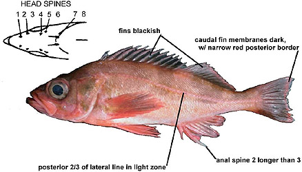

**Body color:** Pink to dark red, w/ dark blotches; posterior 2/3 of lateral line clear.

**Peritoneum color:** dark **Shape between eyes:** flat to convex

**Counts:** D:XIII,13-15, Ar: 6-7, P1:17-19, GR:36-41, LLp:42-52, LLs:46-58, V:27

**Occurence:** Bering Sea - Washington

**Depth:** 100-558 meters **Size:** 37 cm **Species code:** 30535

**Similar species:**

- *Sharpchin rockfish* - lateral line pigmented, dorsal blotches cross w/out break; symphyseal knob prominent; dorsal and caudal fin membranes reddish
- *Redstripe rockfish* - lateral line clear for its entire length, olive mottling dorsally and ventrally; anal spine 2 equal to or shorter than 3; head spines weak
- *Darkblotched rockfish* - body w/ 4 or 5 distinct dark blotches crossing lateral line; body deep, depth > head length; head spine count differs; anal spine 2 shorter than 3
- *Pacific Ocean Perch* - body w/ small discrete dorsal blotches at base of fin; head spines weak and count differs; symphyseal knob prominent (moderate in Harlequin RF)

Back to Group

**Corrections:** If you see mistakes or want to suggest changes, please create an [issue](https://github.com/zoyafuso-NOAA/RACE_Survey_App/issues) on the source repository or

*reach out to Liz Dawson (Liz.Dawson AT noaa.gov).*